# FCC and ACS Pre-processing and EDA

The following document analyzes complaints filed to the Federal Communications Commission (FCC) from January 2021 to July 2022. This data set was pulled from the FCC’s website. To better understand the demographics of the individuals who filed complaints, the FCC data set was merged with a subset of data from the American Community Survey (ACS) which comes from the United States Census Bureau. *Analyzing complaints about spam phone calls was an area of interest.*

**Data Sources:**

- fcc_complaints_CA-2021.csv
- acs_data.csv

**Below is a list of variables that were of importance:**

FCC Data:

- zip - the zip code where the complaint originated from.
- caller_id_number - the phone number from which the spam or robocall came from.
- date_of_issue - the date the incident occurred.
- time_of_issue - the time of day the incident occurred.
- method - how the spam or robocall connected with the individual.

ACS Data:

- name - contains the ZIP code areas.
- median_income - contains the median income in each ZIP code.
- median_age - contains the median age in each ZIP code.
- total_pop - contains the total population within each ZIP code.

```r
library(tidyverse)
```

#### Loading and cleaning column names of data

```r
fcc <- janitor::clean_names(read_csv('fcc_complaints_CA-2021.csv'))
```

#### Filtering out n/a values in zip & method columns

```r
fcc_clean <- fcc %>%
  drop_na(method, zip) %>%
  filter(zip != '00000')
```

#### Creating a new column that extracts tbe area code from caller_id column

```r
fcc_clean <- fcc_clean %>%
  extract(
    col = caller_id_number,
    into = 'area_code',
    regex = "(\\d\\d\\d)",
    remove = F
  )
```

#### Creating separate columns for month and year of entry

```r
fcc_clean$date_of_issue <- lubridate::ymd(fcc_clean$date_of_issue)
fcc_clean <- fcc_clean %>%
  mutate(
    month_of_issue = lubridate::month(date_of_issue, label = T),
    year_of_issue = lubridate::year(date_of_issue)
  )
```

#### Formatting and standardizing time values in column

```r
fcc_clean$time_of_issue <-
  str_replace_all(fcc_clean$time_of_issue, "\\.", '')
fcc_clean <- fcc_clean %>%
  mutate(time_of_issue_clean = parse_time(fcc_clean$time_of_issue))
```

#### Visualizing the distribution of phone complaints by method

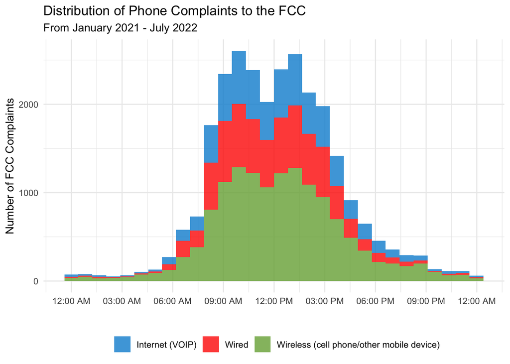

```r
call_distribution <- fcc_clean %>%
  filter(form == "Phone") %>%
  ggplot(aes(time_of_issue_clean, fill = method)) + ## edit the fill
  geom_histogram(alpha = 0.8) +
  theme_minimal() +
  scale_x_time(
    breaks = scales::date_breaks("3 hour"),
    labels = scales::time_format("%I:%M %p")
  ) + ## edit the time_format
  theme(legend.position = "bottom") + ## edit this line
  labs(
    x = "",
    y = "Number of FCC Complaints",
    fill = "",
    title = "Distribution of Phone Complaints to the FCC",
    subtitle = "From January 2021 - July 2022"
  ) +
  ggthemes::scale_fill_fivethirtyeight()
```

#### Reading acs data

```r
acs <- read_csv('acs_data.csv')
```

#### Creating new column of zip code values

```r
acs <- acs %>%
  extract(
    col = name,
    into = 'zip',
    regex = "(\\d\\d\\d\\d\\d)",
    remove = F
  )
```

```r
fcc_joined <- fcc_clean %>%
  merge(acs, by = 'zip') %>%
  filter(year_of_issue == 2021,
         total_pop != 0)
```

#### Creating columns to easily distinguish income and age status of individuals

```r
fcc_joined <- fcc_joined %>%
  mutate(
    low_income_zip = ifelse(
      median_income < mean(median_income, na.rm = T),
      'Below Average Median Income',
      'Above Average Median Income'
    ),
    high_age_zip = ifelse(
      median_age > mean(median_age, na.rm = T),
      'Above Average Median Age',
      'Below Average Median Age'
    )
  )
```

#### Creating a tibble that only includes phone complaints and a tibble that only includes spam complaints

```r
fcc_joined_spam <- fcc_joined %>%
  filter(form == 'Phone' & issue == 'Unwanted Calls')

fcc_joined_phone <- fcc_joined %>%
  filter(form == 'Phone')
```

#### Summarizing the merged tibble to count the numbers of demographic similarities

```r
aggregate <- fcc_joined %>%
  group_by(median_age, median_income, total_pop, zip, low_income_zip) %>%
  summarise(n_complaints = n())
```

[output not shown]

```
## # A tibble: 1,284 × 6
## # Groups:   median_age, median_income, total_pop, zip [1,284]
##    median_age median_income total_pop zip   low_income_zip              n_comp…¹
##         <dbl>         <dbl>     <dbl> <chr> <chr>                          <int>
##  1       10.9            NA        65 95974 <NA>                               1
##  2       19.4            NA      2845 94720 <NA>                               2
##  3       19.6            NA      1624 95211 <NA>                               1
##  4       19.8            NA      3737 92140 <NA>                               2
##  5       20.7         36824     17197 92617 Below Average Median Income        5
##  6       21.8         38125     29597 94704 Below Average Median Income        9
##  7       21.8         45933     35898 93405 Below Average Median Income        9
##  8       21.8            NA       456 92155 <NA>                               1
##  9       22           49750      1653 95903 Below Average Median Income        1
## 10       22.1         54787      9872 92310 Below Average Median Income        1
## # … with 1,274 more rows, and abbreviated variable name ¹n_complaints
```

#### Creating a column that calculates the proportion of complaints per-1000 to adjust for differences in population between zip codes

```r
aggregate <- aggregate %>%
  mutate(complaints_per_1000 = n_complaints/total_pop*1000)
```

#### Adding average median income and average median age to spam call dataset

```r
fcc_joined_spam <- fcc_joined_spam %>%
  mutate(
    low_income_zip =  mean(median_income, na.rm = T),
    high_age_zip =mean(median_age, na.rm = T)
  )
```

#### Counting the number of spam call complaints by zip code

```r
dominant_city <- head(count(fcc_joined_spam, zip, sort = T))
```

```
##     zip   n
## 1 91354 572
## 2 92116 424
## 3 92130 409
## 4 90706 378
## 5 90808 255
## 6 90026 185
```

#### Counting the number of spam call complaints by month

```r
dominant_time_of_year <- head(count(fcc_joined_spam, month_of_issue, sort = T))
```

```
##   month_of_issue    n
## 1            Mar 2372
## 2            Apr 1984
## 3            Feb 1632
## 4            Aug 1632
## 5            Jun 1508
## 6            May 1485
```

#### Counting the number of spam call complaints to the FCC of the dominant income level

```r
dominant_income <- count(fcc_joined_spam, low_income_zip,sort = T) %>%
  drop_na()
colnames(dominant_income) <- c('Income Level', 'Number of Complaints to the FCC')
```

```
##   Income Level Number of Complaints to the FCC
## 1     90142.59                           18731
```

#### Counting the number of spam call complaints to the FCC by the dominant age level

```r
dominant_age <- count(fcc_joined_spam, high_age_zip, sort = T) %>%
  drop_na()
colnames(dominant_age) <- c('Age Level', 'Number of Complaints to the FCC')
```

```
##   Age Level Number of Complaints to the FCC
## 1  38.78833                           18731
```

#### Finding average median income of those that complained about spam calls

```r
average_income <- mean(fcc_joined_spam$median_income, na.rm = T)
```

```
## [1] 90142.59
```

#### Visualizing the number of spam call complaints to the FCC by zip-codes

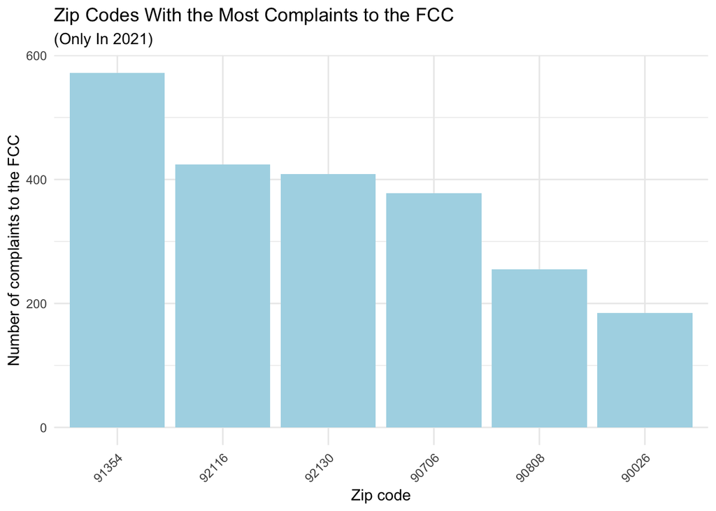

```r
dominant_cities <-head(dominant_city, 10) %>%
  ggplot(aes(x = reorder(zip, -n), y = n)) +
  geom_bar(stat = 'identity', fill="lightblue") +
  labs(x = 'Zip code', y = 'Number of complaints to the FCC', title = "Zip Codes With the Most Complaints to the FCC ",subtitle = '(Only In 2021)') +
  scale_fill_manual(values=c("lightblue")) +
  theme_minimal() +
  theme(axis.text.x = element_text(angle = 45, hjust=1))
```

#### Visualizing the number of spam call complaints to the FCC by the month of the year

[figure not shown]

```r
time_of_year_calls <- dominant_time_of_year %>%
  ggplot(aes(x = month_of_issue, y = n, group = 1)) +
  labs(x = 'Month of the year', y = 'Number of complaints to the FCC', title = 'Number of Complaints to the FCC by Month',subtitle = '(Only In 2021)')+
  geom_line() +
  geom_point()+
  theme_minimal()
```

#### Finding the average median income by zip-code

```r
income_by_zip <- fcc_joined_spam %>%
  group_by(zip) %>%
  summarise(average_median_income = round(mean(median_income, na.rm = T)))
```

```
## # A tibble: 1,272 × 2
##    zip   average_median_income
##    <chr>                 <dbl>
##  1 90001                 43360
##  2 90002                 37285
##  3 90003                 40598
##  4 90004                 49675
##  5 90005                 38491
##  6 90006                 37072
##  7 90007                 27406
##  8 90008                 43364
##  9 90010                 63112
## 10 90011                 40940
## # … with 1,262 more rows
```

#### Merging the data set of the zip-codes with the most complaints and the data set of the average median income of the zip-codes

```r
dominant_city <- merge(dominant_city, income_by_zip, by = 'zip')
dominant_city <- dominant_city[order(dominant_city$n, decreasing = TRUE),]
```

#### Visualizing the number of complaints to FCC by zip-codes and overlaying the respective zip-codes’ average median income

[figure not shown]

```r
dominant_cities_income_graph <-head(dominant_city, 10) %>%
  ggplot(aes(x = reorder(zip, -n), y = n)) +
  geom_bar(stat = 'identity', fill="lightblue") +
  labs(x = 'Zip code', y = 'Number of complaints to the FCC', title = "Zip Codes With the Most Complaints to the FCC",subtitle = '(Only In 2021)') +
  scale_fill_manual(values=c("lightblue")) +
  theme_minimal() +
  geom_text(aes(label=average_median_income, vjust=-0.5, colour = 'average median income '))+
  theme(axis.text.x = element_text(angle = 45, hjust=1))
```

#### Finding the percentage of phone related complaints to the FCC that were about spam calls

```r
spam_percentage <- nrow(fcc_joined_spam)/nrow(fcc_joined_phone)
```

```
## [1] 0.9991465
```

#### Counting the number of complaints to FCC by zip-code

```r
zip_density <- fcc_joined_spam %>%
  count(zip, sort = T)
colnames(zip_density) = c('region', 'value')
```

#### Loading in library for choropleth

```r
library(choroplethrZip)
```

#### Creating choropleth of complaints to FCC by zip-codes in California

[output not shown]

[output cut: 32 more lines]

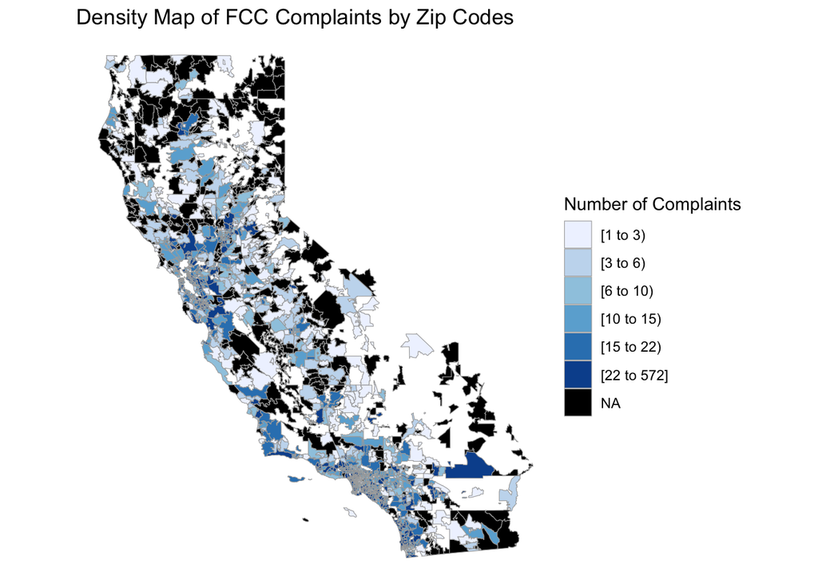

```r
zip_choropleth(zip_density, title = "Density Map of FCC Complaints by Zip Codes", legend = "Number of Complaints", num_colors = 6,
               state_zoom = 'california')
```